# Predicting Workplace Stress Levels Using Machine Learning and HR Data Analysis

```python
import numpy as np # linear algebra
import pandas as pd # data processing, CSV file I/O (e.g. pd.read_csv)
import matplotlib.pyplot as plt
import seaborn as sns
sns.set(style="whitegrid")
data = pd.read_csv('survey.csv')
data.head()
```

|  | Timestamp | Age | Gender | Country | state | self_employed | family_history | treatment | work_interfere | no_employees | ... | leave | mental_health_consequence | phys_health_consequence | coworkers | supervisor | mental_health_interview | phys_health_interview | mental_vs_physical | obs_consequence | comments |
| --- | --- | --- | --- | --- | --- | --- | --- | --- | --- | --- | --- | --- | --- | --- | --- | --- | --- | --- | --- | --- | --- |
| 0 | 2014-08-27 11:29:31 | 37 | Female | United States | IL | NaN | No | Yes | Often | 6-25 | ... | Somewhat easy | No | No | Some of them | Yes | No | Maybe | Yes | No | NaN |
| 1 | 2014-08-27 11:29:37 | 44 | M | United States | IN | NaN | No | No | Rarely | More than 1000 | ... | Don't know | Maybe | No | No | No | No | No | Don't know | No | NaN |
| 2 | 2014-08-27 11:29:44 | 32 | Male | Canada | NaN | NaN | No | No | Rarely | 6-25 | ... | Somewhat difficult | No | No | Yes | Yes | Yes | Yes | No | No | NaN |
| 3 | 2014-08-27 11:29:46 | 31 | Male | United Kingdom | NaN | NaN | Yes | Yes | Often | 26-100 | ... | Somewhat difficult | Yes | Yes | Some of them | No | Maybe | Maybe | No | Yes | NaN |
| 4 | 2014-08-27 11:30:22 | 31 | Male | United States | TX | NaN | No | No | Never | 100-500 | ... | Don't know | No | No | Some of them | Yes | Yes | Yes | Don't know | No | NaN |

5 rows × 27 columns

```python
data.shape
```

```
(1259, 27)
```

Describing features: This dataset contains the following data:

Timestamp

Age

Gender

Country

state: If you live in the United States, which state or territory do you live in?

self_employed: Are you self-employed?

family_history: Do you have a family history of mental illness?

treatment: Have you sought treatment for a mental health condition?

work_interfere: If you have a mental health condition, do you feel that it interferes with your work?

no_employees: How many employees does your company or organization have?

remote_work: Do you work remotely (outside of an office) at least 50% of the time?

tech_company: Is your employer primarily a tech company/organization?

benefits: Does your employer provide mental health benefits?

care_options: Do you know the options for mental health care your employer provides?

wellness_program: Has your employer ever discussed mental health as part of an employee wellness program?

seek_help: Does your employer provide resources to learn more about mental health issues and how to seek help?

anonymity: Is your anonymity protected if you choose to take advantage of mental health or substance abuse treatment resources?

leave: How easy is it for you to take medical leave for a mental health condition?

mental_health_consequence: Do you think that discussing a mental health issue with your employer would have negative consequences?

phys_health_consequence: Do you think that discussing a physical health issue with your employer would have negative consequences?

coworkers: Would you be willing to discuss a mental health issue with your coworkers?

supervisor: Would you be willing to discuss a mental health issue with your direct supervisor(s)?

mental_health_interview: Would you bring up a mental health issue with a potential employer in an interview?

phys_health_interview: Would you bring up a physical health issue with a potential employer in an interview?

mental_vs_physical: Do you feel that your employer takes mental health as seriously as physical health?

obs_consequence: Have you heard of or observed negative consequences for coworkers with mental health conditions in your workplace?

comments: Any additional notes or comments

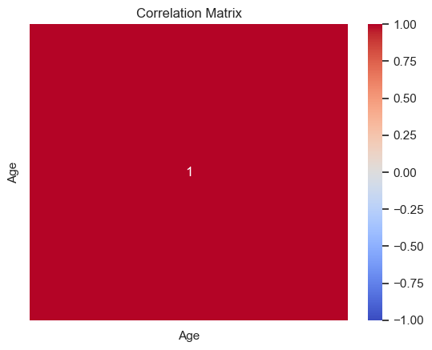

```python
import numpy as np
import pandas as pd
import matplotlib.pyplot as plt
import seaborn as sns

sns.set(style="whitegrid")

data = pd.read_csv('survey.csv')

# Create correlation matrix
corr_matrix = data.corr()

# Plot correlation matrix using heatmap
sns.heatmap(corr_matrix, annot=True, cmap='coolwarm', vmin=-1, vmax=1)

plt.title('Correlation Matrix')
plt.show()
```

# as we can see only age is a numerical data let us do preprocessing

```python
data.drop(['Timestamp', 'state', 'comments'], axis=1, inplace=True)
```

[output not shown]

[output cut: 16 more lines]

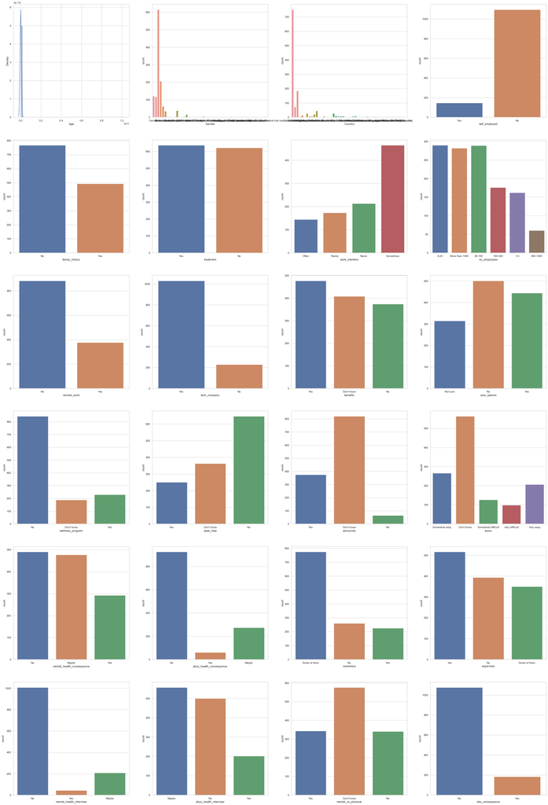

```python
# Visualizing features
fig = plt.figure(figsize = (40,70))
for i, col in enumerate(data.columns):
    ax = fig.add_subplot(7, 4, i+1)
    if col=='Age':
        sns.distplot(data[col], ax=ax)
    elif col=='Timestamp':
        pass
    else:
        sns.countplot(data[col], ax=ax)
```

# DATA PRE-PROCESSING

```python
data.Gender.value_counts()
```

```
Male                                              615
male                                              206
Female                                            121
M                                                 116
female                                             62
F                                                  38
m                                                  34
f                                                  15
Make                                                4
Male                                                3
Woman                                               3
Cis Male                                            2
Man                                                 2
Female (trans)                                      2
Female                                              2
Trans woman                                         1
msle                                                1
male leaning androgynous                            1
Neuter                                              1
cis male                                            1
queer                                               1
Female (cis)                                        1
Mail                                                1
cis-female/femme                                    1
A little about you                                  1
Malr                                                1
p                                                   1
femail                                              1
Cis Man                                             1
Guy (-ish) ^_^                                      1
Enby                                                1
Agender                                             1
Androgyne                                           1
Male-ish                                            1
maile                                               1
Trans-female                                        1
Cis Female                                          1
something kinda male?                               1
Mal                                                 1
Male (CIS)                                          1
queer/she/they                                      1
non-binary                                          1
Femake                                              1
woman                                               1
Nah                                                 1
All                                                 1
fluid                                               1
Genderqueer                                         1
ostensibly male, unsure what that really means      1
Name: Gender, dtype: int64
```

```python
data['Gender'] = data['Gender'].str.lower().str.strip()
data['Gender'].value_counts().keys()
```

```
Index(['male', 'female', 'm', 'f', 'woman', 'make', 'cis male',
       'female (trans)', 'man', 'male leaning androgynous', 'trans woman',
       'msle', 'neuter', 'mail', 'queer', 'female (cis)', 'cis-female/femme',
       'a little about you', 'malr', 'p', 'femail', 'cis man',
       'guy (-ish) ^_^', 'fluid', 'agender', 'male (cis)', 'male-ish', 'maile',
       'trans-female', 'cis female', 'something kinda male?', 'mal',
       'queer/she/they', 'androgyne', 'non-binary', 'femake', 'nah', 'all',
       'enby', 'genderqueer',
       'ostensibly male, unsure what that really means'],
      dtype='object')
```

```python
male_words = ['m', 'male', 'make', 'cis male', 'man', 'something kinda male?', 'malr', 'male (cis)', 'maile', 'mal', 'guy (-ish) ^_^'
             'male-ish', 'cis man', 'msle', 'male leaning androgynous', 'ostensibly male, unsure what that really means', 'mail']
female_words = ['f', 'female', 'woman', 'femake', 'fluid', 'cis-female/femme', 'female (cis)', 'cis female', 'femail',]

other_words = []
for word in data['Gender'].value_counts().keys():
    if (word not in male_words) & (word not in female_words):
        other_words.append(word)
other_words
```

```
['female (trans)',
 'trans woman',
 'neuter',
 'queer',
 'a little about you',
 'p',
 'guy (-ish) ^_^',
 'agender',
 'male-ish',
 'trans-female',
 'queer/she/they',
 'androgyne',
 'non-binary',
 'nah',
 'all',
 'enby',
 'genderqueer']
```

```python
dict_replace = {}
dict_replace.update(dict.fromkeys(male_words, 'm'))
dict_replace.update(dict.fromkeys(female_words, 'f'))
dict_replace.update(dict.fromkeys(other_words, 'o'))
dict_replace
```

```
{'m': 'm',
 'male': 'm',
 'make': 'm',
 'cis male': 'm',
 'man': 'm',
 'something kinda male?': 'm',
 'malr': 'm',
 'male (cis)': 'm',
 'maile': 'm',
 'mal': 'm',
 'guy (-ish) ^_^male-ish': 'm',
 'cis man': 'm',
 'msle': 'm',
 'male leaning androgynous': 'm',
 'ostensibly male, unsure what that really means': 'm',
 'mail': 'm',
 'f': 'f',
 'female': 'f',
 'woman': 'f',
 'femake': 'f',
 'fluid': 'f',
 'cis-female/femme': 'f',
 'female (cis)': 'f',
 'cis female': 'f',
 'femail': 'f',
 'female (trans)': 'o',
 'trans woman': 'o',
 'neuter': 'o',
 'queer': 'o',
 'a little about you': 'o',
 'p': 'o',
 'guy (-ish) ^_^': 'o',
 'agender': 'o',
 'male-ish': 'o',
 'trans-female': 'o',
 'queer/she/they': 'o',
 'androgyne': 'o',
 'non-binary': 'o',
 'nah': 'o',
 'all': 'o',
 'enby': 'o',
 'genderqueer': 'o'}
```

```python
data['Gender'] = data['Gender'].replace(dict_replace)
data['Gender'].value_counts()
```

```
m    993
f    248
o     18
Name: Gender, dtype: int64
```

```python
data.head()
```

|  | Age | Gender | Country | self_employed | family_history | treatment | work_interfere | no_employees | remote_work | tech_company | ... | anonymity | leave | mental_health_consequence | phys_health_consequence | coworkers | supervisor | mental_health_interview | phys_health_interview | mental_vs_physical | obs_consequence |
| --- | --- | --- | --- | --- | --- | --- | --- | --- | --- | --- | --- | --- | --- | --- | --- | --- | --- | --- | --- | --- | --- |
| 0 | 37 | f | United States | NaN | No | Yes | Often | 6-25 | No | Yes | ... | Yes | Somewhat easy | No | No | Some of them | Yes | No | Maybe | Yes | No |
| 1 | 44 | m | United States | NaN | No | No | Rarely | More than 1000 | No | No | ... | Don't know | Don't know | Maybe | No | No | No | No | No | Don't know | No |
| 2 | 32 | m | Canada | NaN | No | No | Rarely | 6-25 | No | Yes | ... | Don't know | Somewhat difficult | No | No | Yes | Yes | Yes | Yes | No | No |
| 3 | 31 | m | United Kingdom | NaN | Yes | Yes | Often | 26-100 | No | Yes | ... | No | Somewhat difficult | Yes | Yes | Some of them | No | Maybe | Maybe | No | Yes |
| 4 | 31 | m | United States | NaN | No | No | Never | 100-500 | Yes | Yes | ... | Don't know | Don't know | No | No | Some of them | Yes | Yes | Yes | Don't know | No |

5 rows × 24 columns

```python
data.isnull().any()
```

```
Age                          False
Gender                       False
Country                      False
self_employed                 True
family_history               False
treatment                    False
work_interfere                True
no_employees                 False
remote_work                  False
tech_company                 False
benefits                     False
care_options                 False
wellness_program             False
seek_help                    False
anonymity                    False
leave                        False
mental_health_consequence    False
phys_health_consequence      False
coworkers                    False
supervisor                   False
mental_health_interview      False
phys_health_interview        False
mental_vs_physical           False
obs_consequence              False
dtype: bool
```

```python
data['Country'].value_counts()
```

```
United States             751
United Kingdom            185
Canada                     72
Germany                    45
Ireland                    27
Netherlands                27
Australia                  21
France                     13
India                      10
New Zealand                 8
Poland                      7
Switzerland                 7
Sweden                      7
Italy                       7
South Africa                6
Belgium                     6
Brazil                      6
Israel                      5
Singapore                   4
Bulgaria                    4
Austria                     3
Finland                     3
Mexico                      3
Russia                      3
Denmark                     2
Greece                      2
Colombia                    2
Croatia                     2
Portugal                    2
Moldova                     1
Georgia                     1
Bahamas, The                1
China                       1
Thailand                    1
Czech Republic              1
Norway                      1
Romania                     1
Nigeria                     1
Japan                       1
Hungary                     1
Bosnia and Herzegovina      1
Uruguay                     1
Spain                       1
Zimbabwe                    1
Latvia                      1
Costa Rica                  1
Slovenia                    1
Philippines                 1
Name: Country, dtype: int64
```

```python
data.self_employed.value_counts()
```

```
No     1095
Yes     146
Name: self_employed, dtype: int64
```

```python
data.isnull().sum()
```

```
Age                            0
Gender                         0
Country                        0
self_employed                 18
family_history                 0
treatment                      0
work_interfere               264
no_employees                   0
remote_work                    0
tech_company                   0
benefits                       0
care_options                   0
wellness_program               0
seek_help                      0
anonymity                      0
leave                          0
mental_health_consequence      0
phys_health_consequence        0
coworkers                      0
supervisor                     0
mental_health_interview        0
phys_health_interview          0
mental_vs_physical             0
obs_consequence                0
dtype: int64
```

```python
data['self_employed'].replace({'Yes':1, 'No':0, np.nan:0}, inplace=True)
data.self_employed.value_counts()
```

```
0.0    1113
1.0     146
Name: self_employed, dtype: int64
```

```python
data['family_history'].value_counts()
```

```
No     767
Yes    492
Name: family_history, dtype: int64
```

```python
data['family_history'].replace({'Yes':1, 'No':0}, inplace=True)
```

```python
data['treatment'].value_counts()
```

```
Yes    637
No     622
Name: treatment, dtype: int64
```

```python
data['treatment'].replace({'Yes':1, 'No':0}, inplace=True)
```

```python
data['work_interfere'].value_counts()
```

```
Sometimes    465
Never        213
Rarely       173
Often        144
Name: work_interfere, dtype: int64
```

```python
data.loc[data.treatment==1, 'work_interfere']
```

```
0           Often
3           Often
6       Sometimes
8       Sometimes
10      Sometimes
          ...
1252    Sometimes
1254          NaN
1255        Often
1256    Sometimes
1258    Sometimes
Name: work_interfere, Length: 637, dtype: object
```

```python
data['work_interfere'].replace({np.nan:-1, 'Never':0, 'Rarely':1, 'Sometimes':2, 'Often':3}, inplace=True)
```

```python
data.no_employees.value_counts()
```

```
6-25              290
26-100            289
More than 1000    282
100-500           176
1-5               162
500-1000           60
Name: no_employees, dtype: int64
```

```python
data['no_employees'].replace({'1-5':3, '6-25':15.5, '26-100':63, '100-500':300, '500-1000':750, 'More than 1000':1000}, inplace=True)
```

```python
data.remote_work.value_counts()
```

```
No     883
Yes    376
Name: remote_work, dtype: int64
```

```python
data['remote_work'].replace({'Yes':1, 'No':0}, inplace=True)
```

```python
data['tech_company'].value_counts()
```

```
Yes    1031
No      228
Name: tech_company, dtype: int64
```

```python
data['tech_company'].replace({'Yes':1, 'No':0}, inplace=True)
```

```python
data['benefits'].value_counts()
```

```
Yes           477
Don't know    408
No            374
Name: benefits, dtype: int64
```

```python
data['benefits'].replace({'Yes':1, 'No':-1, 'Don\'t know':0}, inplace=True)
```

```python
data['care_options'].value_counts()
```

```
No          501
Yes         444
Not sure    314
Name: care_options, dtype: int64
```

```python
data['care_options'].replace({'Yes':1, 'No':-1, 'Not sure':0}, inplace=True)
```

```python
data['wellness_program'].value_counts
```

```
<bound method IndexOpsMixin.value_counts of 0               No
1       Don't know
2               No
3               No
4       Don't know
           ...
1254            No
1255            No
1256            No
1257            No
1258            No
Name: wellness_program, Length: 1259, dtype: object>
```

```python
data['wellness_program'].replace({'Yes':1, 'No':-1, 'Don\'t know':0}, inplace=True)
```

```python
data['seek_help'].value_counts()
```

```
No            646
Don't know    363
Yes           250
Name: seek_help, dtype: int64
```

```python
data['seek_help'].replace({'Yes':1, 'No':-1, 'Don\'t know':0}, inplace=True)
```

```python
data['anonymity'].value_counts()
```

```
Don't know    819
Yes           375
No             65
Name: anonymity, dtype: int64
```

```python
data['anonymity'].replace({'Yes':1, 'No':-1, 'Don\'t know':0}, inplace=True)
```

```python
data['leave'].value_counts()
```

```
Don't know            563
Somewhat easy         266
Very easy             206
Somewhat difficult    126
Very difficult         98
Name: leave, dtype: int64
```

```python
data['leave'].replace({'Very difficult':-2, 'Somewhat difficult':-1, 'Don\'t know':0, 'Somewhat easy':1, 'Very easy':2}, inplace=True)
```

```python
data['mental_health_consequence'].value_counts()
```

```
No       490
Maybe    477
Yes      292
Name: mental_health_consequence, dtype: int64
```

```python
data['mental_health_consequence'].replace({'Yes':1, 'No':-1, 'Maybe':0}, inplace=True)
```

```python
data['phys_health_consequence'].value_counts()
```

```
No       925
Maybe    273
Yes       61
Name: phys_health_consequence, dtype: int64
```

```python
data['phys_health_consequence'].replace({'Yes':1, 'No':-1, 'Maybe':0}, inplace=True)
```

```python
data['coworkers'].value_counts()
```

```
Some of them    774
No              260
Yes             225
Name: coworkers, dtype: int64
```

```python
data['coworkers'].replace({'Yes':1, 'No':-1, 'Some of them':0}, inplace=True)
```

```python
data['supervisor'].value_counts()
```

```
Yes             516
No              393
Some of them    350
Name: supervisor, dtype: int64
```

```python
data['supervisor'].replace({'Yes':1, 'No':-1, 'Some of them':0}, inplace=True)
```

```python
data['mental_health_interview'].value_counts()
```

```
No       1008
Maybe     207
Yes        44
Name: mental_health_interview, dtype: int64
```

```python
data['mental_health_interview'].replace({'Yes':1, 'No':-1, 'Maybe':0}, inplace=True)
```

```python
data['phys_health_interview'].value_counts()
```

```
Maybe    557
No       500
Yes      202
Name: phys_health_interview, dtype: int64
```

```python
data['phys_health_interview'].replace({'Yes':1, 'No':-1, 'Maybe':0}, inplace=True)
```

```python
data['mental_vs_physical'].value_counts()
```

```
Don't know    576
Yes           343
No            340
Name: mental_vs_physical, dtype: int64
```

```python
data['mental_vs_physical'].replace({'Yes':1, 'No':-1, 'Don\'t know':0}, inplace=True)
```

```python
data['obs_consequence'].value_counts()
```

```
No     1075
Yes     184
Name: obs_consequence, dtype: int64
```

```python
data['obs_consequence'].replace({'Yes':1, 'No':0}, inplace=True)
```

# Data PRE-PROCESSING ENDS HERE

```python
data.head()
```

|  | Age | Gender | Country | self_employed | family_history | treatment | work_interfere | no_employees | remote_work | tech_company | ... | anonymity | leave | mental_health_consequence | phys_health_consequence | coworkers | supervisor | mental_health_interview | phys_health_interview | mental_vs_physical | obs_consequence |
| --- | --- | --- | --- | --- | --- | --- | --- | --- | --- | --- | --- | --- | --- | --- | --- | --- | --- | --- | --- | --- | --- |
| 0 | 37 | f | United States | 0.0 | 0 | 1 | 3 | 15.5 | 0 | 1 | ... | 1 | 1 | -1 | -1 | 0 | 1 | -1 | 0 | 1 | 0 |
| 1 | 44 | m | United States | 0.0 | 0 | 0 | 1 | 1000.0 | 0 | 0 | ... | 0 | 0 | 0 | -1 | -1 | -1 | -1 | -1 | 0 | 0 |
| 2 | 32 | m | Canada | 0.0 | 0 | 0 | 1 | 15.5 | 0 | 1 | ... | 0 | -1 | -1 | -1 | 1 | 1 | 1 | 1 | -1 | 0 |
| 3 | 31 | m | United Kingdom | 0.0 | 1 | 1 | 3 | 63.0 | 0 | 1 | ... | -1 | -1 | 1 | 1 | 0 | -1 | 0 | 0 | -1 | 1 |
| 4 | 31 | m | United States | 0.0 | 0 | 0 | 0 | 300.0 | 1 | 1 | ... | 0 | 0 | -1 | -1 | 0 | 1 | 1 | 1 | 0 | 0 |

5 rows × 24 columns

# Calculate the correlation

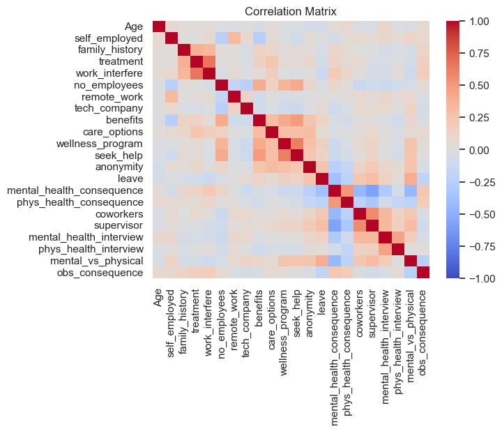

```python
# Create correlation matrix
corr_matrix = data.corr()

# Plot correlation matrix using heatmap
sns.heatmap(corr_matrix, cmap='coolwarm', vmin=-1, vmax=1)

plt.title('Correlation Matrix')
plt.show()
```

```python
# One Hot Encoding on gender
final_data = pd.get_dummies(data=data, columns=['Gender', 'Country'], drop_first=True)
# Extracting the labels (target variables)
treatment = final_data.treatment
final_data.drop(['treatment'], axis=1, inplace = True)
final_data.head()
```

|  | Age | self_employed | family_history | work_interfere | no_employees | remote_work | tech_company | benefits | care_options | wellness_program | ... | Country_Slovenia | Country_South Africa | Country_Spain | Country_Sweden | Country_Switzerland | Country_Thailand | Country_United Kingdom | Country_United States | Country_Uruguay | Country_Zimbabwe |
| --- | --- | --- | --- | --- | --- | --- | --- | --- | --- | --- | --- | --- | --- | --- | --- | --- | --- | --- | --- | --- | --- |
| 0 | 37 | 0.0 | 0 | 3 | 15.5 | 0 | 1 | 1 | 0 | -1 | ... | 0 | 0 | 0 | 0 | 0 | 0 | 0 | 1 | 0 | 0 |
| 1 | 44 | 0.0 | 0 | 1 | 1000.0 | 0 | 0 | 0 | -1 | 0 | ... | 0 | 0 | 0 | 0 | 0 | 0 | 0 | 1 | 0 | 0 |
| 2 | 32 | 0.0 | 0 | 1 | 15.5 | 0 | 1 | -1 | -1 | -1 | ... | 0 | 0 | 0 | 0 | 0 | 0 | 0 | 0 | 0 | 0 |
| 3 | 31 | 0.0 | 1 | 3 | 63.0 | 0 | 1 | -1 | 1 | -1 | ... | 0 | 0 | 0 | 0 | 0 | 0 | 1 | 0 | 0 | 0 |
| 4 | 31 | 0.0 | 0 | 0 | 300.0 | 1 | 1 | 1 | -1 | 0 | ... | 0 | 0 | 0 | 0 | 0 | 0 | 0 | 1 | 0 | 0 |

5 rows × 70 columns

# Splitting of Data

```python
from sklearn.model_selection import train_test_split
X_train, X_test, y_train, y_test = train_test_split(final_data, treatment, test_size=0.3, random_state=2)
```

# Calculate the multicollinearity

```python
# Check for multicollinearity using the variance inflation factor (VIF)
from statsmodels.stats.outliers_influence import variance_inflation_factor

# Create a function to calculate the VIF
def calculate_vif(X):
    vif = pd.DataFrame()
    vif["Features"] = X.columns
    vif["VIF"] = [variance_inflation_factor(X.values, i) for i in range(X.shape[1])]
    return vif

# Calculate the VIF for each feature in the selected feature set
vif = calculate_vif(pd.DataFrame(X_train))

print(vif)
```

```
                  Features           VIF
0                      Age  3.002400e+15
1            self_employed  1.518175e+00
2           family_history  1.950872e+00
3           work_interfere  1.974077e+00
4             no_employees  2.470716e+00
..                     ...           ...
65        Country_Thailand  1.045635e+00
66  Country_United Kingdom  3.024041e+00
67   Country_United States  1.101756e+01
68         Country_Uruguay           NaN
69        Country_Zimbabwe  3.002400e+15

[70 rows x 2 columns]
```

# BUILDING MODELS

```python
# Import necessary libraries
from sklearn.linear_model import LogisticRegression
from sklearn.tree import DecisionTreeClassifier
from sklearn.ensemble import RandomForestClassifier
from sklearn.neighbors import KNeighborsClassifier
from sklearn.svm import SVC

# Instantiate models
logistic_reg = LogisticRegression()
decision_tree = DecisionTreeClassifier()
random_forest = RandomForestClassifier()
knn = KNeighborsClassifier()
svm = SVC()

# Fit models on training data
logistic_reg.fit(X_train, y_train)
decision_tree.fit(X_train, y_train)
random_forest.fit(X_train, y_train)
knn.fit(X_train, y_train)
svm.fit(X_train, y_train)

# Evaluate models on training and test data
print("Logistic Regression Training Accuracy:", logistic_reg.score(X_train, y_train))
print("Logistic Regression Test Accuracy:", logistic_reg.score(X_test, y_test))
print("Decision Tree Training Accuracy:", decision_tree.score(X_train, y_train))
print("Decision Tree Test Accuracy:", decision_tree.score(X_test, y_test))
print("Random Forest Training Accuracy:", random_forest.score(X_train, y_train))
print("Random Forest Test Accuracy:", random_forest.score(X_test, y_test))
print("KNN Training Accuracy:", knn.score(X_train, y_train))
print("KNN Test Accuracy:", knn.score(X_test, y_test))
print("SVM Training Accuracy:", svm.score(X_train, y_train))
print("SVM Test Accuracy:", svm.score(X_test, y_test))
```

```
Logistic Regression Training Accuracy: 0.492622020431328
Logistic Regression Test Accuracy: 0.5370370370370371
Decision Tree Training Accuracy: 1.0
Decision Tree Test Accuracy: 0.7116402116402116
Random Forest Training Accuracy: 1.0
Random Forest Test Accuracy: 0.8121693121693122
KNN Training Accuracy: 0.8365493757094211
KNN Test Accuracy: 0.7275132275132276
```

```
SVM Training Accuracy: 0.5085130533484676
SVM Test Accuracy: 0.46296296296296297
```

# DOING FEATURE SELECTION FOR THE MODELS AND FINDING BEST MODEL

```python
# Import necessary libraries
from sklearn.linear_model import LogisticRegression
from sklearn.tree import DecisionTreeClassifier
from sklearn.ensemble import RandomForestClassifier
from sklearn.neighbors import KNeighborsClassifier
from sklearn.svm import SVC
from sklearn.feature_selection import SelectKBest, f_classif

# Define the number of features to select
k = 10

# Instantiate feature selector
selector = SelectKBest(f_classif, k=k)

# Fit feature selector on training data
selector.fit(X_train, y_train)

# Transform training and test data to selected features
X_train_selected = selector.transform(X_train)
X_test_selected = selector.transform(X_test)

# Instantiate models
logistic_reg = LogisticRegression()
decision_tree = DecisionTreeClassifier()
random_forest = RandomForestClassifier()
knn = KNeighborsClassifier()
svm = SVC()

# Fit models on training data with selected features
logistic_reg.fit(X_train_selected, y_train)
decision_tree.fit(X_train_selected, y_train)
random_forest.fit(X_train_selected, y_train)
knn.fit(X_train_selected, y_train)
svm.fit(X_train_selected, y_train)

# Evaluate models on test data with selected features
logistic_reg_acc = logistic_reg.score(X_test_selected, y_test)
decision_tree_acc = decision_tree.score(X_test_selected, y_test)
random_forest_acc = random_forest.score(X_test_selected, y_test)
knn_acc = knn.score(X_test_selected, y_test)
svm_acc = svm.score(X_test_selected, y_test)

# Find the best performing model
best_model = max([logistic_reg_acc, decision_tree_acc, random_forest_acc, knn_acc, svm_acc])

# Print the test accuracies of each model
print("Logistic Regression Test Accuracy:", logistic_reg_acc)
print("Decision Tree Test Accuracy:", decision_tree_acc)
print("Random Forest Test Accuracy:", random_forest_acc)
print("KNN Test Accuracy:", knn_acc)
print("SVM Test Accuracy:", svm_acc)

# Print the best performing model
if best_model == logistic_reg_acc:
    print("Best Model: Logistic Regression")
elif best_model == decision_tree_acc:
    print("Best Model: Decision Tree")
elif best_model == random_forest_acc:
    print("Best Model: Random Forest")
elif best_model == knn_acc:
    print("Best Model: KNN")
else:
    print("Best Model: SVM")
```

```
Logistic Regression Test Accuracy: 0.8227513227513228
Decision Tree Test Accuracy: 0.7486772486772487
Random Forest Test Accuracy: 0.7936507936507936
KNN Test Accuracy: 0.8068783068783069
SVM Test Accuracy: 0.8386243386243386
Best Model: SVM
```